# skewness and kurtosis analysis

Johnny Zhang

April 29, 2024

## Get data into R

```r
load("analysis20250108.RData")
```

We have observed that researchers may have analyzed the same data set multiple times. To avoid the redundant information, we took a liberal method to remove duplicated results. We compared the skewness, kurtosis, and their associated standard error estimates of each row of data. If they are the same, we removed the duplicated row.

The final data set include 272,963 unique univariate measures and 18,865 unique multivariate measures.

### Regarding sample size

```r
n <- multi.data.unique$n
p <- multi.data.unique$p
summary(n)
```

```
##     Min.  1st Qu.   Median     Mean  3rd Qu.     Max.
##      4.0    166.0    284.0    486.1    409.0 104022.0
```

```r
summary(p)
```

```
##    Min. 1st Qu.  Median    Mean 3rd Qu.    Max.
##    1.00    5.00    7.00   17.43   18.00  543.00
```

We noticed the rather small sample sizes for some analysis. For example, 120 studies had sample size smaller than 10 and 459 studies had sample size smaller than 30. There are 95 studies with sample size greater than 5000. In this research, we excluded studies with sample size < 30 and sample size greater than 5,000. After it, we have a total of 18311 analyses left.

```r
multi.sub <- multi.data.unique[n > 29 & n<5001, ]
nrow(multi.sub)
```

```
## [1] 18311
```

We now take a look at the basic information of the analysis. We first take a look at the number of analysis each month over time.

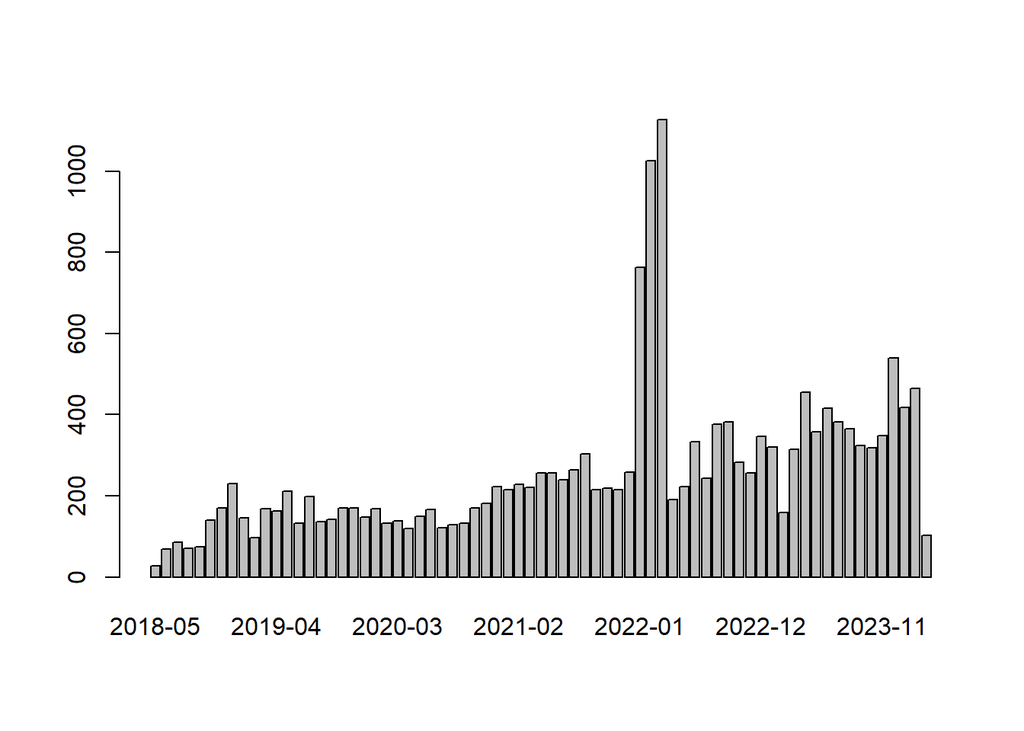

```r
multi.sub$time.group <- as.character(multi.sub$time)
multi.sub$time.group <- substr(multi.sub$time.group, 1, 7)
barplot(table(multi.sub$time.group))
```

We now take a look at the sample sizes.

```r
n <- multi.sub$n
p <- multi.sub$p

summary(n) ## sample size
```

```
##    Min. 1st Qu.  Median    Mean 3rd Qu.    Max.
##    30.0   177.0   294.0   338.4   409.0  5000.0
```

```r
summary(p) ## number of variables
```

```
##    Min. 1st Qu.  Median    Mean 3rd Qu.    Max.
##    1.00    5.00    7.00   17.55   19.00  507.00
```

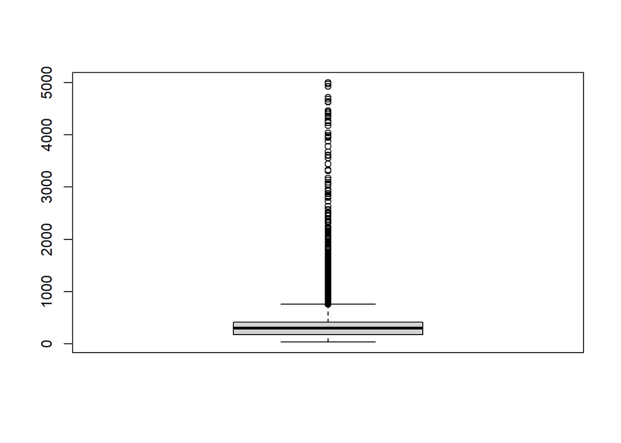

```r
boxplot(n)
```

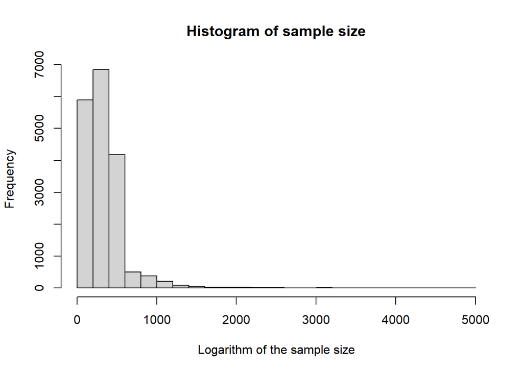

```r
hist(n, main="Histogram of sample size", xlab="Logarithm of the sample size", nclass=20)
```

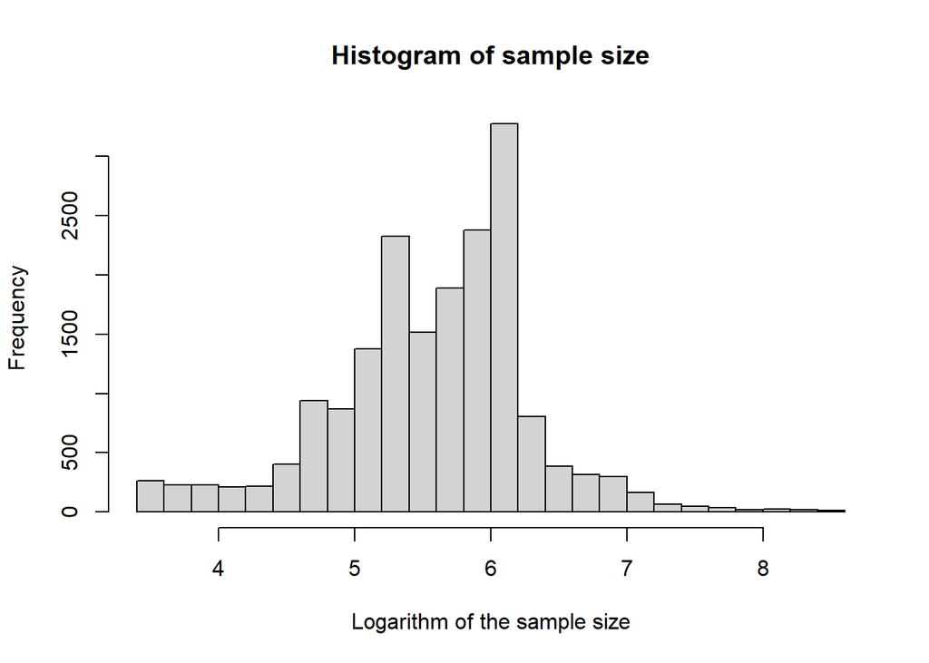

```r
hist(log(n), main="Histogram of sample size", xlab="Logarithm of the sample size", nclass=20)
```

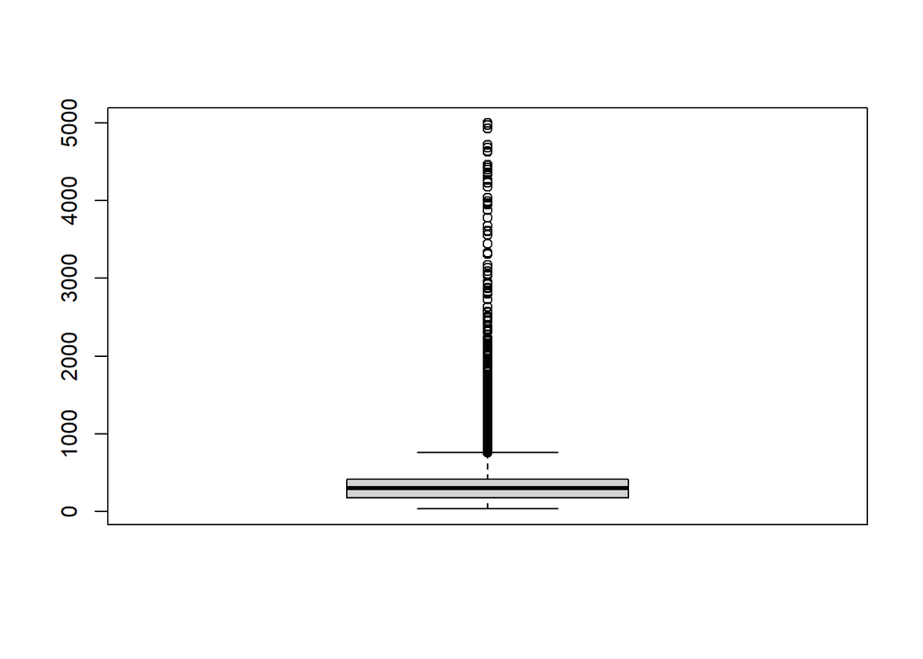

```r
boxplot(n)
```

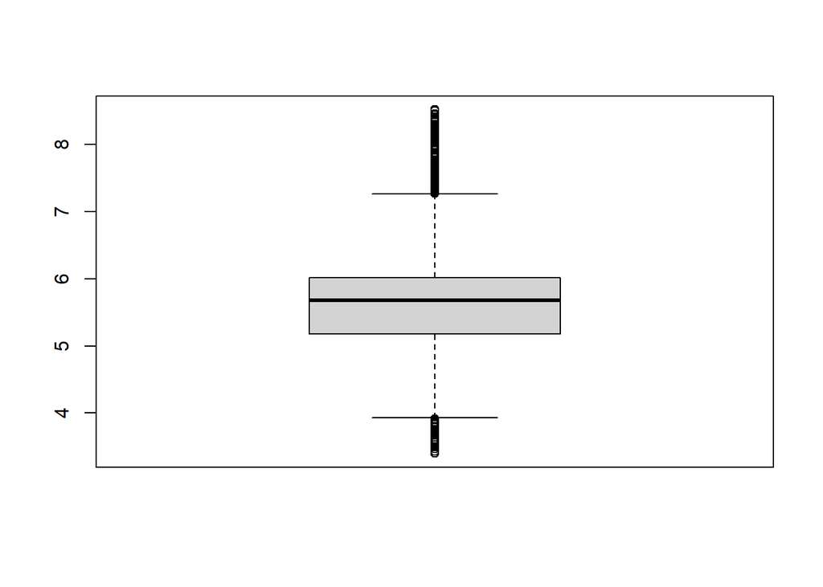

```r
boxplot(log(n))
```

The number of variables

```r
summary(p)
```

```
##    Min. 1st Qu.  Median    Mean 3rd Qu.    Max.
##    1.00    5.00    7.00   17.55   19.00  507.00
```

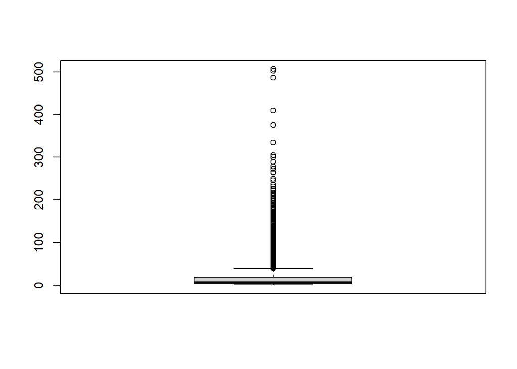

```r
boxplot(p)
```

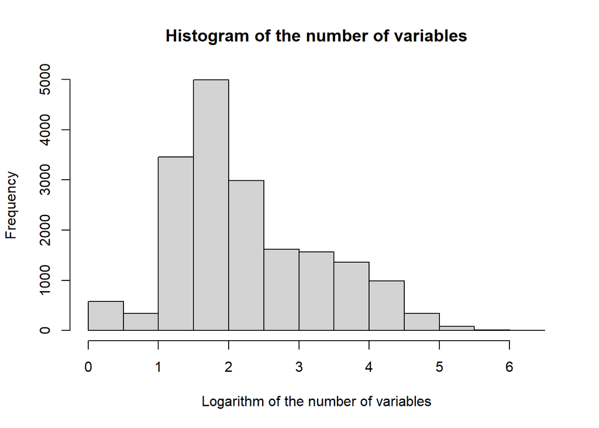

```r
hist(log(p), main="Histogram of the number of variables", xlab="Logarithm of the number of variables", nclass=20)
```

```r
summary(n/p)
```

```
##      Min.   1st Qu.    Median      Mean   3rd Qu.      Max.
##    0.1074   11.7778   31.3750   57.5080   68.1667 2879.0000
```

We now get the percentile of the sample size and the number of variables at .01, .05, .1, .25, .5, .75, .9, .95, .99.

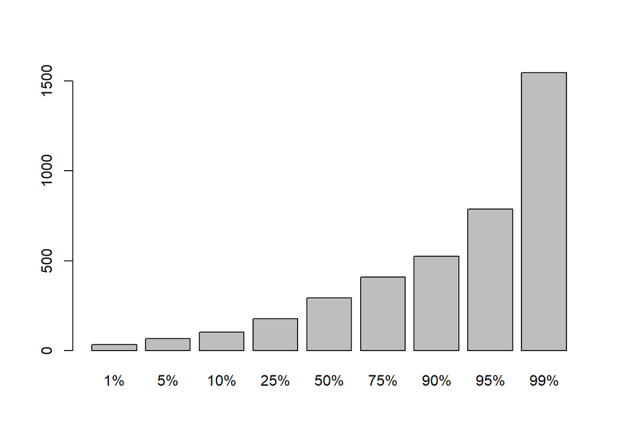

```r
np <- quantile(n, c(0.01, 0.05, 0.1, 0.25, 0.5, 0.75, 0.9, 0.95, 0.99))
pp <- quantile(p, c(0.01, 0.05, 0.1, 0.25, 0.5, 0.75, 0.9, 0.95, 0.99))
barplot(np)
```

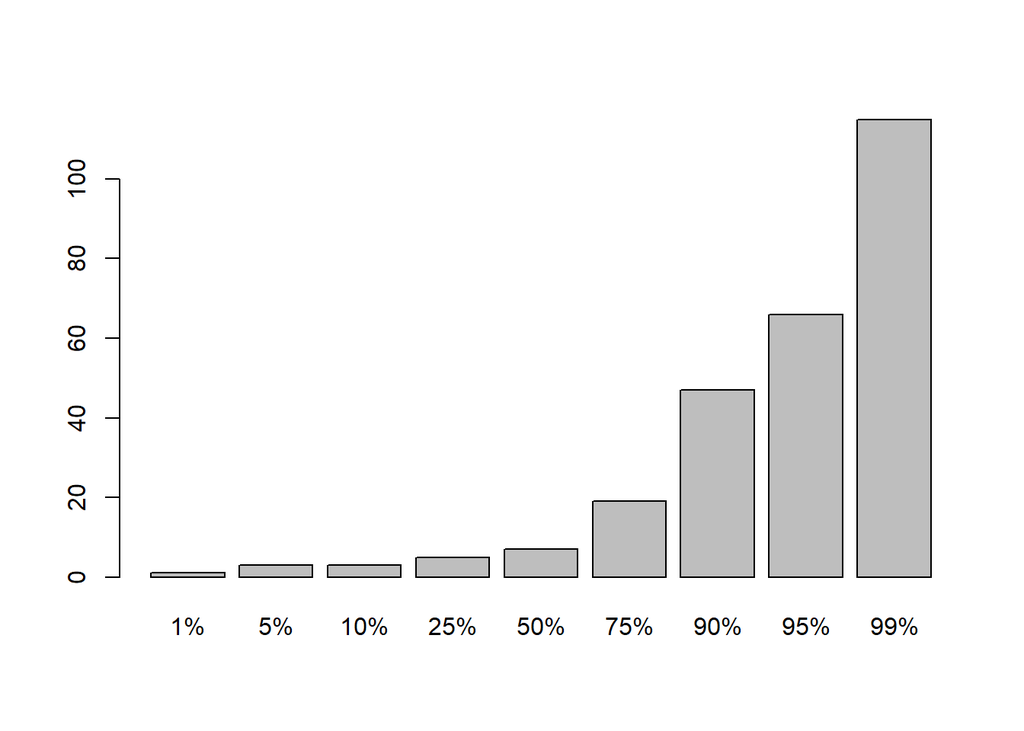

```r
barplot(pp)
```

### Univariate skewness and kurtosis

We also remove the analysis with the sample size smaller than 30, which leads to 266,934 single variables in the whole data set.

```r
uni.info <- uni.info[uni.info$n > 29  & uni.info$n<5001, ]
nrow(uni.info)
```

```
## [1] 266934
```

#### Look at the distribution of skewness

Take out the complete data for skewness and look at its distribution.

```r
skew.data <- uni.info$Skewness
length(skew.data)
```

```
## [1] 266934
```

```r
skew.se <- uni.info$SE_skew
skew.z <- skew.data/skew.se

summary(skew.data)
```

```
##     Min.  1st Qu.   Median     Mean  3rd Qu.     Max.
## -43.4390  -0.7793  -0.3757  -0.2650   0.0400  66.8210
```

```r
## quantiles of skewness
t(t(quantile(skew.data, c(0.0001, .001, .005, 0.01, .025, .05, .1, .2, .25, .3, .4, .5, .6, .7, .75, .8, .9, .95, 0.975, 0.99, .995, .999, .9999))))
```

```
##                [,1]
## 0.01%  -14.14384020
## 0.1%    -6.29570348
## 0.5%    -2.95100000
## 1%      -2.33100000
## 2.5%    -1.82177315
## 5%      -1.48924710
## 10%     -1.19050510
## 20%     -0.88300000
## 25%     -0.77931225
## 30%     -0.69000000
## 40%     -0.52600000
## 50%     -0.37571570
## 60%     -0.22200000
## 70%     -0.05300000
## 75%      0.03999581
## 80%      0.16200000
## 90%      0.62967846
## 95%      1.18001434
## 97.5%    1.82700000
## 99%      3.53239353
## 99.5%    5.81001000
## 99.9%   16.32360565
## 99.99%  37.72101540
```

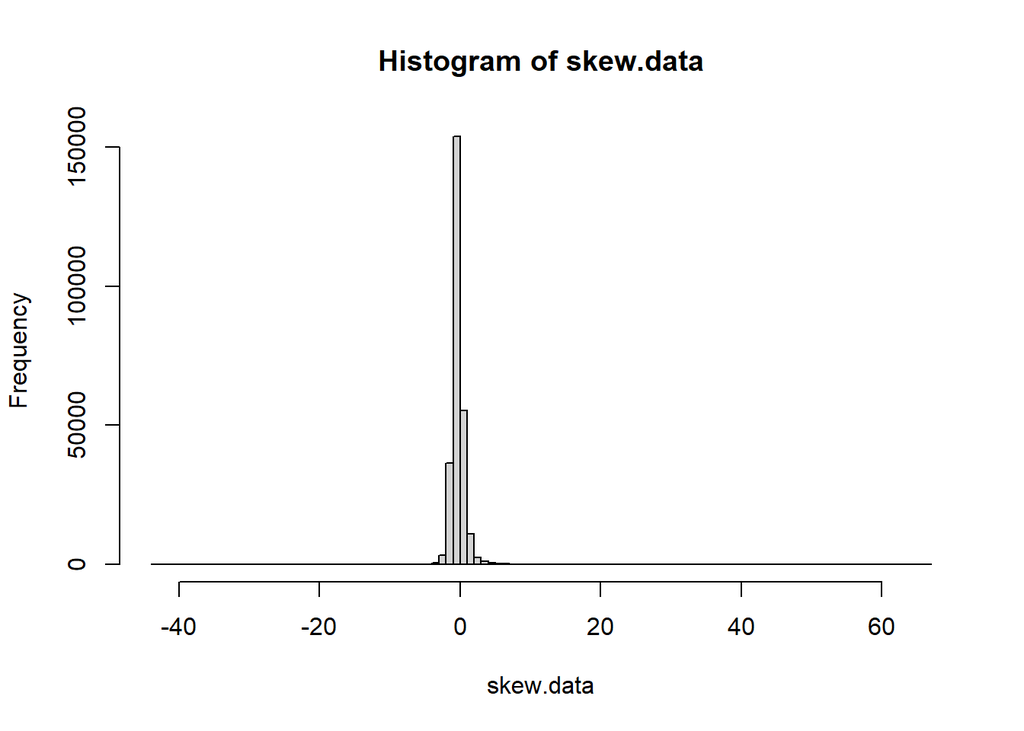

```r
hist(skew.data, breaks = 100)
```

The skewness mostly (99.2%) lies between -5 and 5. We now take a closer look at the density of the skewness between -5 and 5.

```r
## we now plot the density between -5 and 5 only, 99.2% of the data
mean(skew.data > -5 & skew.data < 5)
```

```
## [1] 0.9921891
```

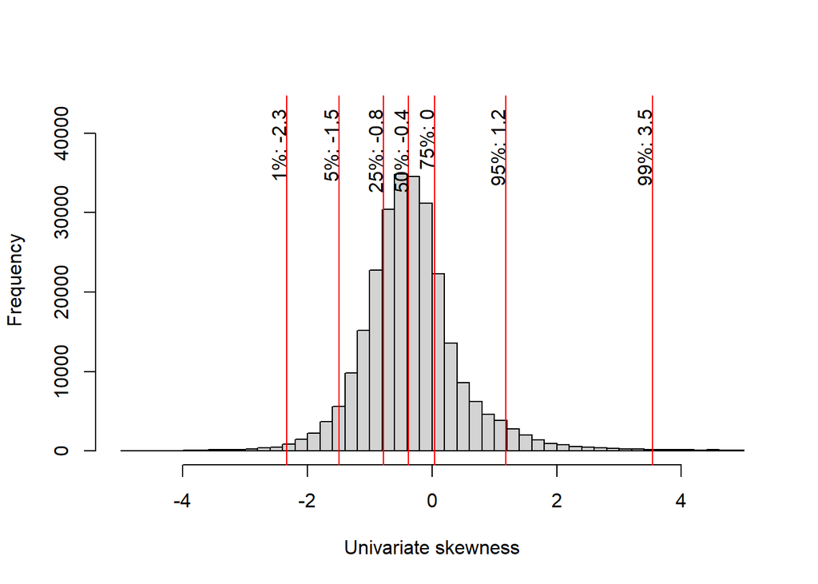

```r
#pdf('uni_skewness.pdf')
hist(skew.data[skew.data > -5 & skew.data < 5], breaks=50,
     main='', xlab='Univariate skewness', ylim=c(0, 43000))
abline(v=quantile(skew.data, prob=c(.01, .05, .25, 0.5, .75, .95, .99)), col='red')
par(srt=90)
text(quantile(skew.data, prob=c(.01, .05, .25, 0.5, .75, .95, .99)), 43000, labels=paste(c('1%', '5%', '25%', '50%', '75%', '95%', '99%'), round(quantile(skew.data, prob=c(.01, .05, .25, 0.5, .75, .95, .99)), 1), sep=': '), pos=2, offset=0.3)
```

```r
#dev.off()
```

Now take a look at the z-score and size of skewness.

```r
mean(abs(skew.z) > qnorm(0.975))
```

```
## [1] 0.7023983
```

```r
mean(abs(skew.data) < .05)
```

```
## [1] 0.05290072
```

```r
mean(abs(skew.data) < .1)
```

```
## [1] 0.1028456
```

```r
mean(abs(skew.data) < .2)
```

```
## [1] 0.1999408
```

```r
mean(abs(skew.data) < .3)
```

```
## [1] 0.2926454
```

```r
mean(abs(skew.data) < .4)
```

```
## [1] 0.3803
```

```r
mean(abs(skew.data) < .5)
```

```
## [1] 0.4655758
```

We now take a look at the association between the sample size and the skewness and Z-score.

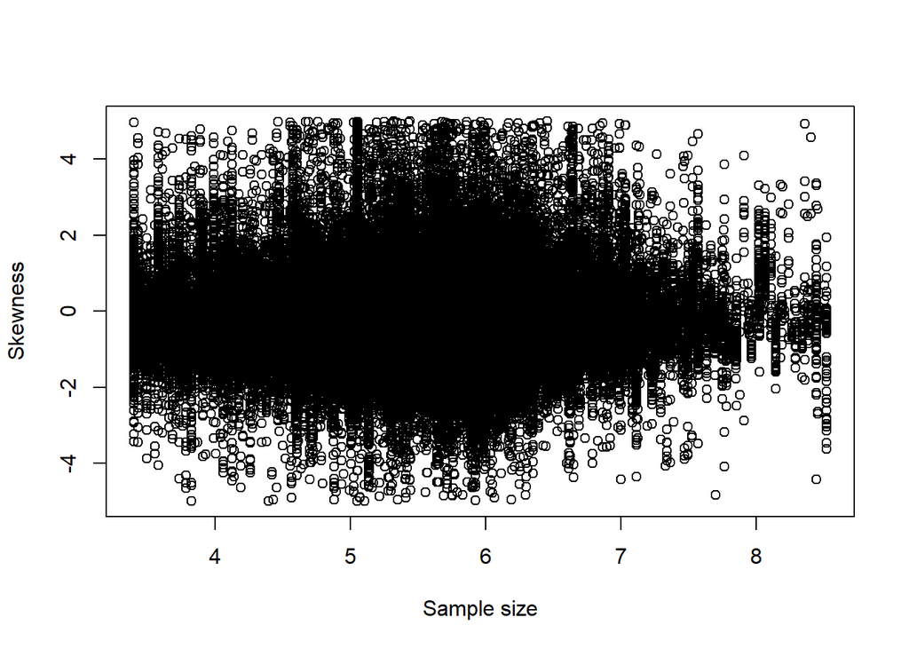

```r
uni.info.selected <- uni.info[uni.info$Skewness > -5 & uni.info$Skewness < 5, ]

plot(log(uni.info.selected$n), uni.info.selected$Skewness,
     xlab='Sample size', ylab='Skewness')
```

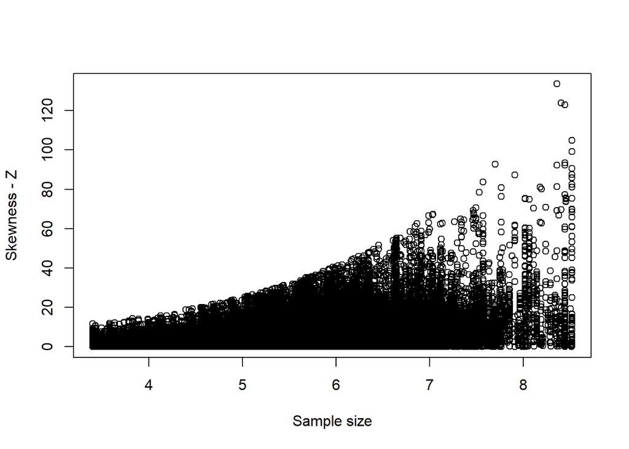

```r
plot(log(uni.info.selected$n), abs(uni.info.selected$Skewness/uni.info.selected$SE_skew),
     xlab='Sample size', ylab='Skewness - Z')
```

#### Look at the distribution of kurtosis

The minimum sample kurtosis is -2.148 for uniform distribution. The maximum kurtosis is 4465 in our data. Data with outliers can easily have a kurtosis as big as this.

```r
kurt.data <- uni.info$Kurtosis
kurt.se <- uni.info$SE_kurt
kurt.z <- kurt.data/kurt.se

length(kurt.data)
```

```
## [1] 266934
```

```r
summary(kurt.data)
```

```
##     Min.  1st Qu.   Median     Mean  3rd Qu.     Max.
##   -2.148   -0.606   -0.047    1.944    0.819 4465.000
```

```r
## quantiles of kurtosis

t(t(quantile(kurt.data, c(0.0001, .001, .005, 0.01, .025, .05, .1, .2, .25, .3, .4, .5, .6, .7, .75, .8, .9, .95, 0.975, 0.99, .995, .999, .9999))))
```

```
##                 [,1]
## 0.01%    -2.08706656
## 0.1%     -2.01348563
## 0.5%     -1.89733500
## 1%       -1.65877130
## 2.5%     -1.36200000
## 5%       -1.18979780
## 10%      -0.98500000
## 20%      -0.71500000
## 25%      -0.60639412
## 30%      -0.49900000
## 40%      -0.28000000
## 50%      -0.04745397
## 60%       0.22500000
## 70%       0.57828457
## 75%       0.81900000
## 80%       1.14500000
## 90%       2.41644004
## 95%       4.23554355
## 97.5%     7.83703540
## 99%      22.87102000
## 99.5%    50.64380330
## 99.9%   327.00000000
## 99.99% 1647.87360150
```

```r
mean(kurt.data < 0)
```

```
## [1] 0.5190197
```

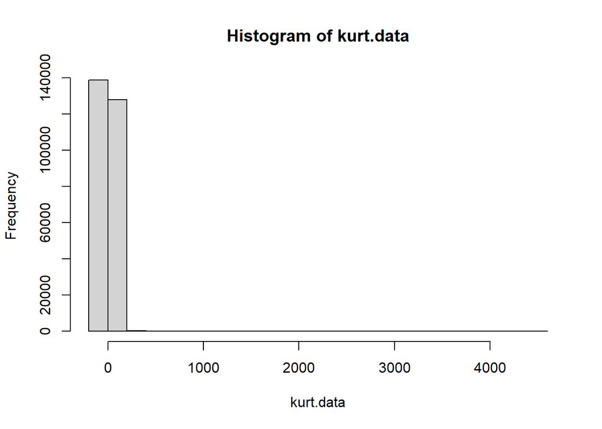

```r
hist(kurt.data)
```

The majority of the kurtosis lies between -2 and 15. We now take a closer look at the density of the kurtosis between -2 and 15.

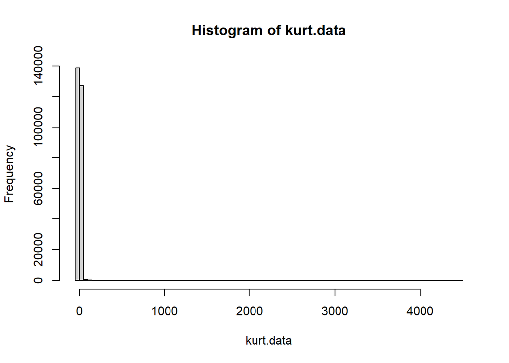

```r
hist.kurt <- hist(kurt.data, breaks = 100)
```

```r
##
mean(kurt.data < 15)
```

```
## [1] 0.9859553
```

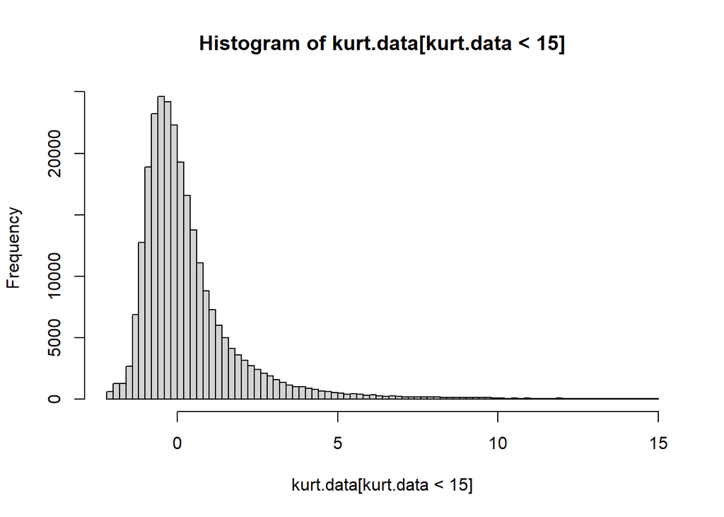

```r
hist(kurt.data[kurt.data < 15], breaks=100)
```

```r
pdf('uni_kurtosis.pdf')
hist(kurt.data[kurt.data < 15], main='', xlab='Univariate kurtosis', breaks=50, ylim=c(0, 70000))

abline(v=quantile(kurt.data, prob=c(.01, .05, .25, 0.5, .75, .95, .99)), col='red')
par(srt=90)
text(quantile(kurt.data, prob=c(.01, .05, .25, 0.5, .75, .95, .99)), 70000, labels=paste(c('1%', '5%', '25%', '50%', '75%', '95%', '99%'), round(quantile(kurt.data, prob=c(.01, .05, .25, 0.5, .75, .95, .99)), 1), sep=': '), pos=2, offset=0.3)
text(14, 65000, labels='99%: 22.8')
dev.off()
```

Now take a look at the z-score for kurtosis

```r
mean(abs(kurt.z) > qnorm(0.975))
```

```
## [1] 0.5488173
```

The proportion of univariate variables with significant skewness or kurtosis

```r
mean(abs(skew.z) > qnorm(0.975))
```

```
## [1] 0.7023983
```

```r
mean(abs(skew.z) > qnorm(0.975) | abs(kurt.z) > qnorm(0.975))
```

```
## [1] 0.8417287
```

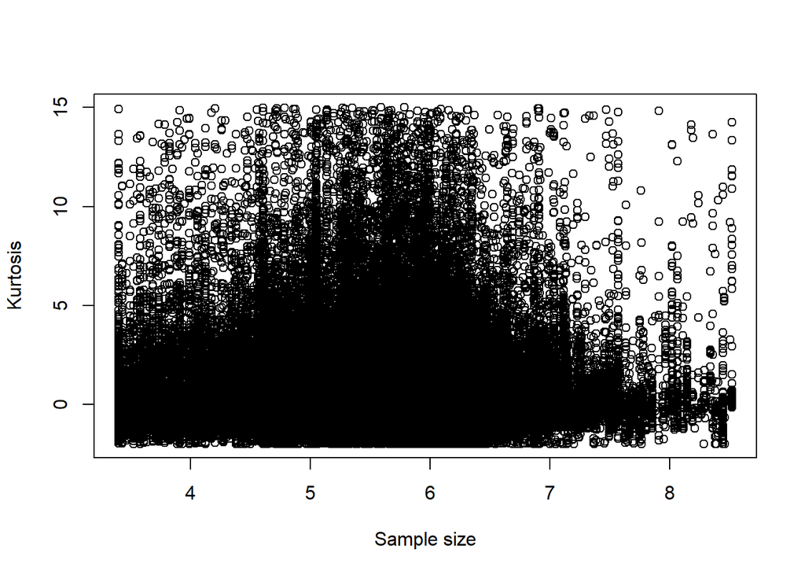

```r
uni.info.selected <- uni.info[uni.info$Kurtosis > -2 & uni.info$Kurtosis < 15, ]

plot(log(uni.info.selected$n), uni.info.selected$Kurtosis,
     xlab='Sample size', ylab='Kurtosis')
```

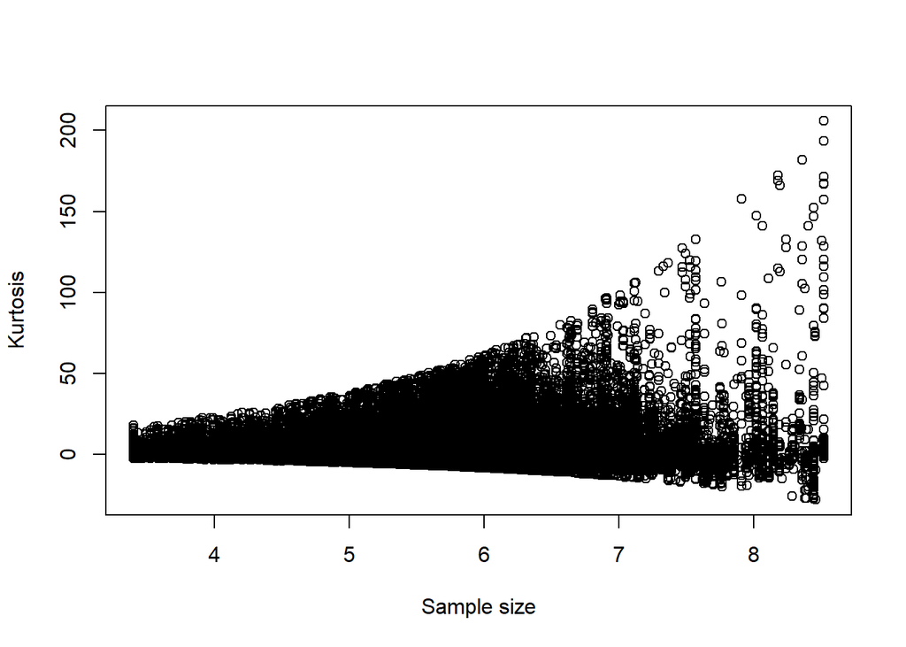

```r
plot(log(uni.info.selected$n), uni.info.selected$Kurtosis/uni.info.selected$SE_kurt,
     xlab='Sample size', ylab='Kurtosis')
```

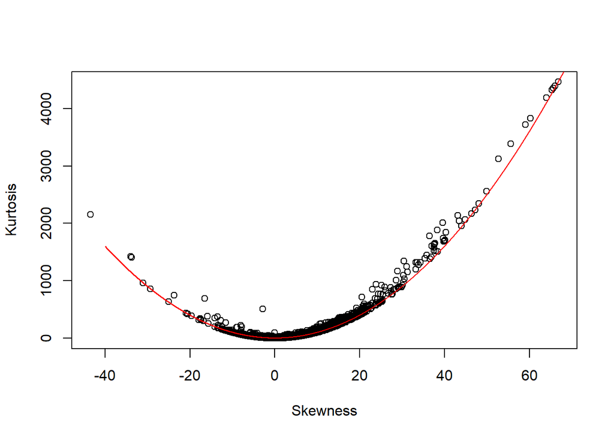

```r
plot(skew.data, kurt.data, xlab='Skewness', ylab='Kurtosis')

skew.sim <-seq(-40, 100, length=length(kurt.data))
kurt.sim <- skew.sim^2 + 1
lines(skew.sim, kurt.sim, col='red')
```

### Multivariate skewness and kurtosis

Distribution of multivariate skewness. The minimum multivariate skewness is 0 and the maximum is 64947 but 97.5% of them is smaller than 2,940.

```r
mul.info <- multi.sub
## skewness
m.skew <- mul.info[, 5]
m.skew.pvalue <- mul.info[, 7]

mean(m.skew.pvalue < 0.05)
```

```
## [1] 0.8996778
```

```r
summary(m.skew)
```

```
##     Min.  1st Qu.   Median     Mean  3rd Qu.     Max.
##     0.00     3.45    12.14   327.38    86.50 64947.19
```

```r
## quantiles of multivariate skewness
t(t(quantile(m.skew, c(0.0001, .001, .005, 0.01, .025, .05, .1, .2, .25, .3, .4, .5, .6, .7, .75, .8, .9, .95, 0.975, 0.99, .995, .999, .9999))))
```

```
##                [,1]
## 0.01%  3.091715e-06
## 0.1%   2.114398e-04
## 0.5%   1.157302e-02
## 1%     5.474753e-02
## 2.5%   2.732738e-01
## 5%     5.472683e-01
## 10%    1.099088e+00
## 20%    2.628286e+00
## 25%    3.446578e+00
## 30%    4.510297e+00
## 40%    7.278717e+00
## 50%    1.213831e+01
## 60%    2.189882e+01
## 70%    4.996173e+01
## 75%    8.649515e+01
## 80%    1.665824e+02
## 90%    6.872657e+02
## 95%    1.518133e+03
## 97.5%  2.939596e+03
## 99%    5.559020e+03
## 99.5%  8.503973e+03
## 99.9%  2.069925e+04
## 99.99% 4.256562e+04
```

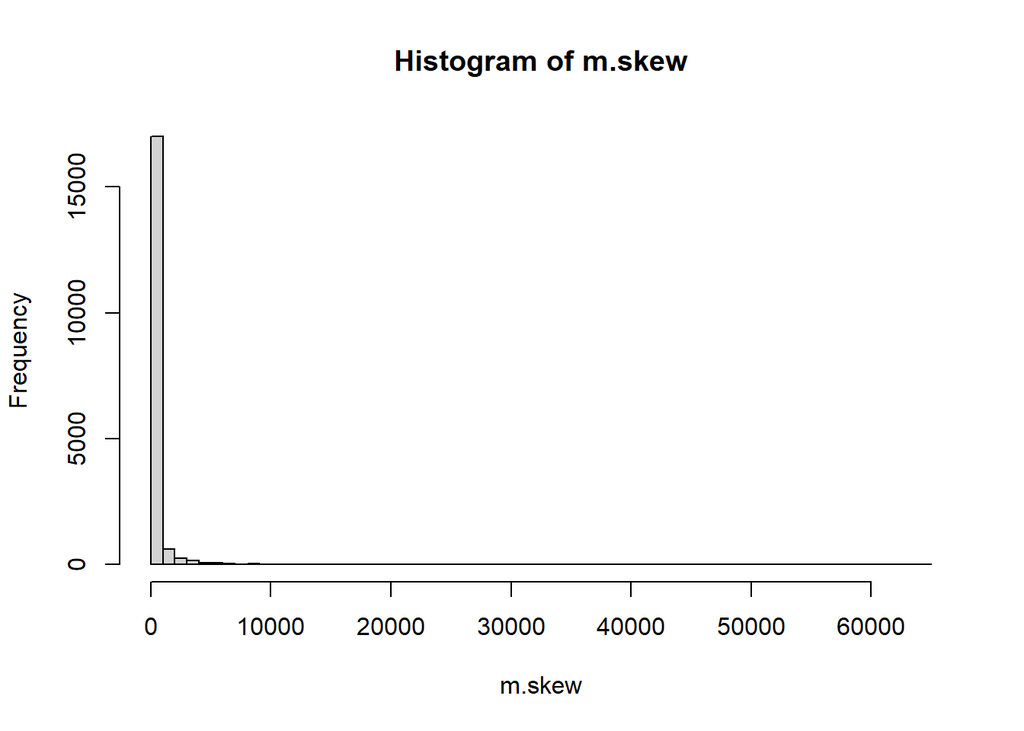

```r
## histogram of multivariate skewness
hist(m.skew, breaks = 50)
```

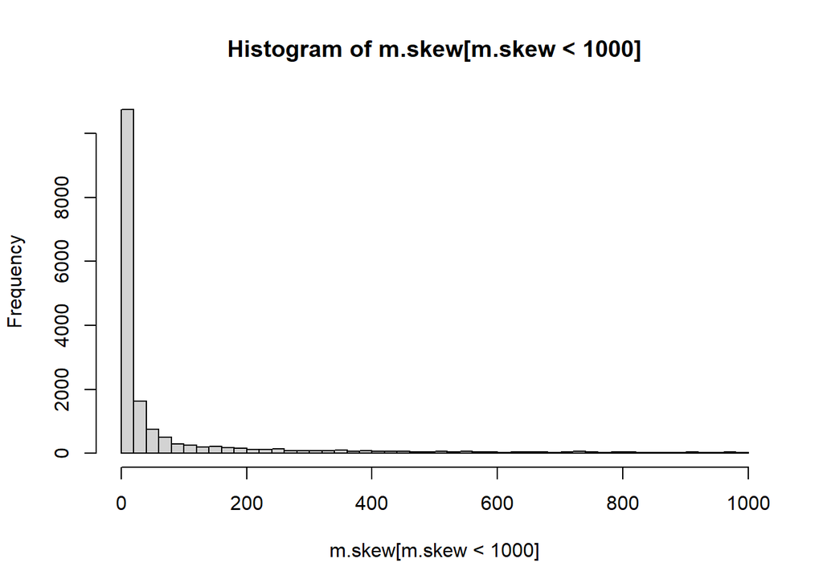

```r
hist(m.skew[m.skew < 1000], breaks = 50)
```

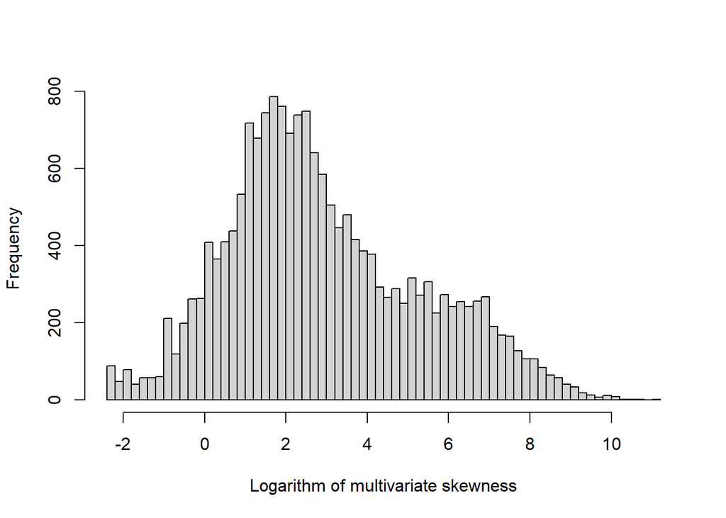

```r
hist(log(m.skew+0.1), main="", xlab="Logarithm of multivariate skewness", breaks = 50)
```

We now look at the association between multivarate skewness and the sample size and the number of variables.

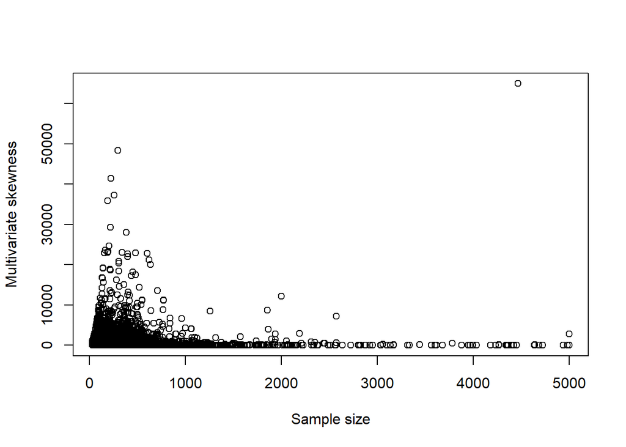

```r
## skewness and sample size
plot(n, m.skew, xlab='Sample size', ylab='Multivariate skewness')
```

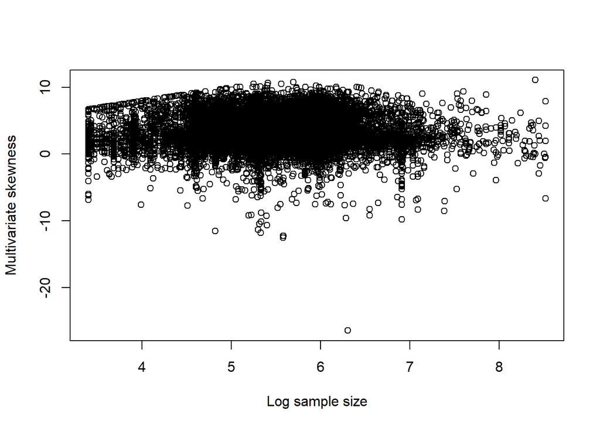

```r
plot(log(n), log(m.skew), xlab='Log sample size', ylab='Multivariate skewness')
```

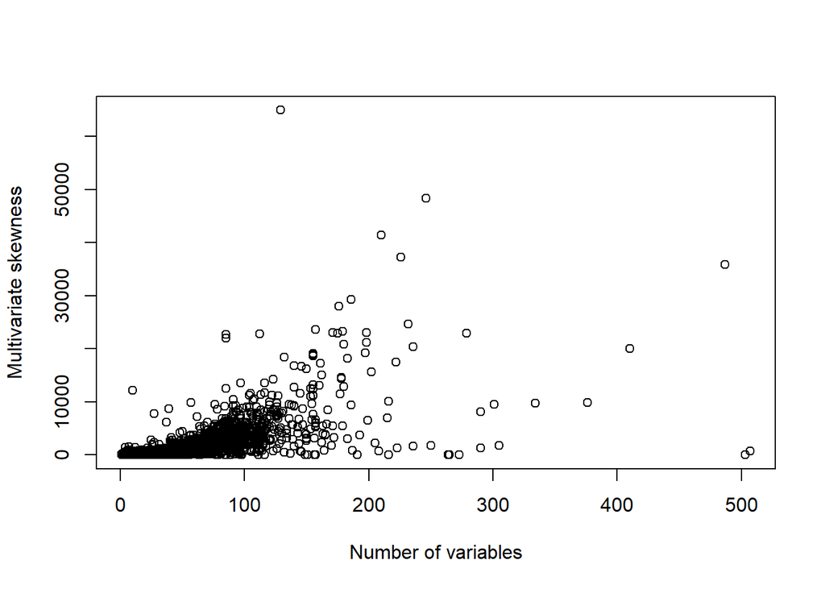

```r
## skewness and number of variables
plot(p, m.skew, xlab='Number of variables', ylab='Multivariate skewness')
```

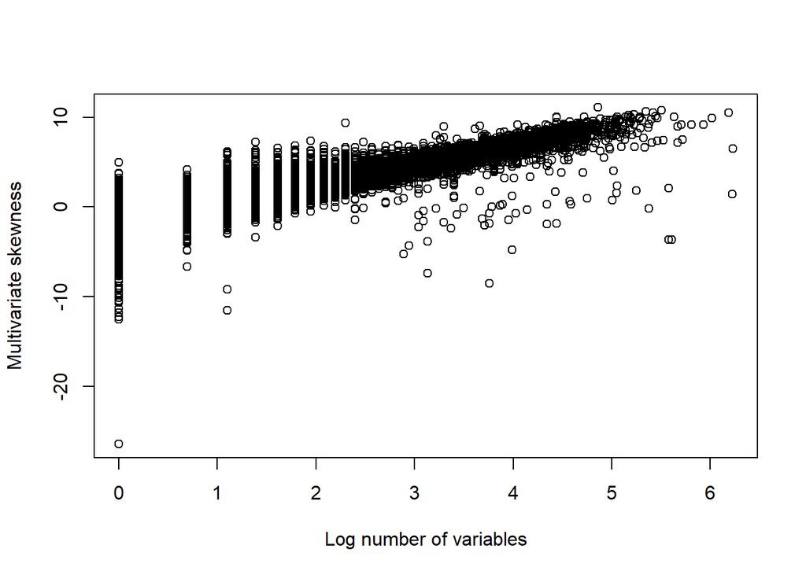

```r
plot(log(p), log(m.skew), xlab='Log number of variables', ylab='Multivariate skewness')
```

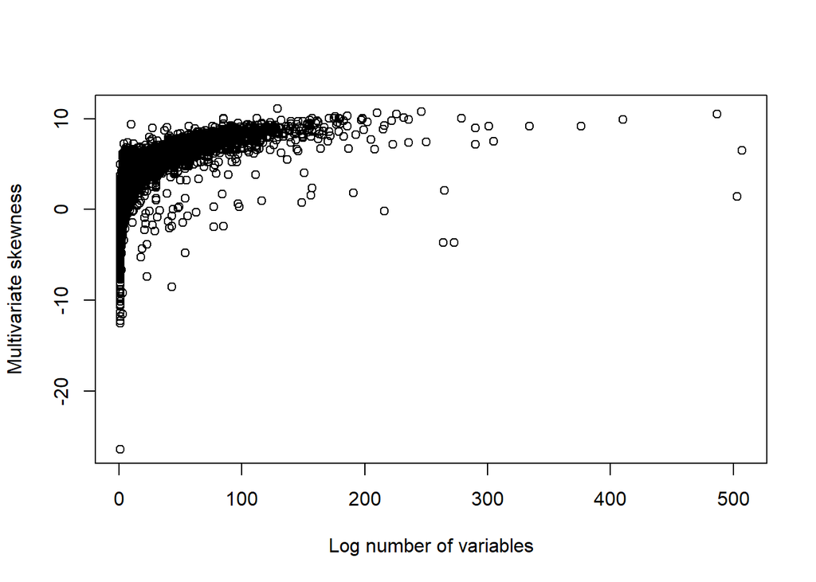

```r
plot(p, log(m.skew), xlab='Log number of variables', ylab='Multivariate skewness')
```

Other visualization of multivariate skewness.

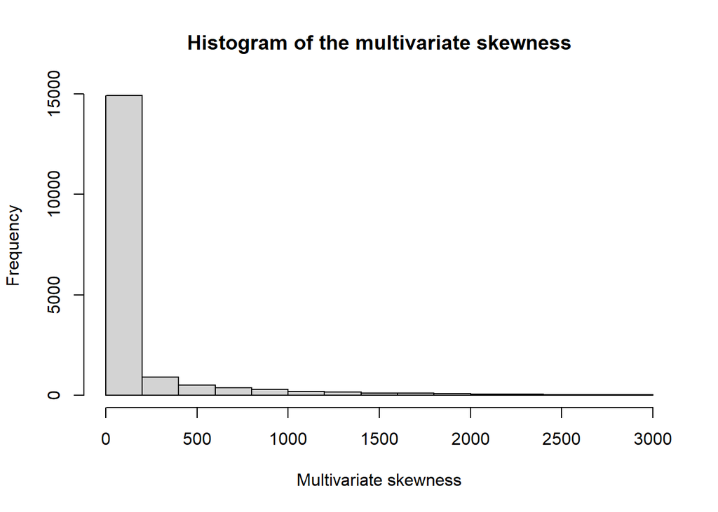

```r
hist(m.skew[m.skew < 2940], main='Histogram of the multivariate skewness', xlab='Multivariate skewness')
```

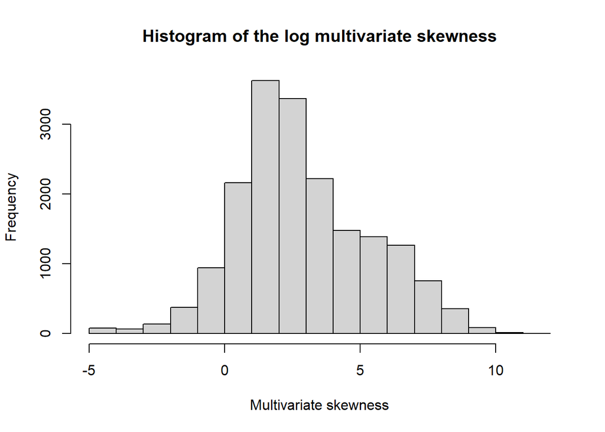

```r
hist(log(m.skew+0.01), main='Histogram of the log multivariate skewness', xlab='Multivariate skewness')
```

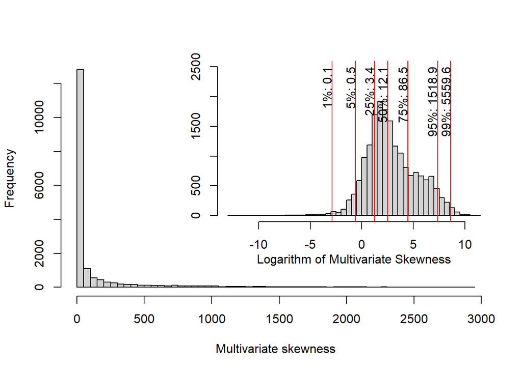

```r
### plot of the multivariate skewness
m.skew.old <- m.skew
#pdf('mult_skewness.pdf')
m.skew <- m.skew[m.skew > quantile(m.skew, .0001)]
hist(m.skew[m.skew < 2940], main='', xlab='Multivariate skewness', breaks=50)
par(fig=c(0.3, 1, 0.2, 1), new=TRUE, mgp=c(2, 1, 0))
hist(log(m.skew), main='', xlab='Logarithm of Multivariate Skewness', ylab='', ylim=c(0, 2500), breaks=50)
abline(v=quantile(log(m.skew), prob=c(.01, .05, .25, 0.5, .75, .95, .99)), col='red')
par(srt=90)
text(quantile(log(m.skew), prob=c(.01, .05, .25, 0.5, .75, .95, .99)), 2500, labels=paste(c('1%', '5%', '25%', '50%', '75%', '95%', '99%'), round(quantile(m.skew, prob=c(.01, .05, .25, 0.5, .75, .95, .99)), 1), sep=': '), pos=2, offset=0.3)
```

```r
par(mgp=c(3, 1, 0))
#dev.off()
```

Now take a look at the kurtosis

```r
## kurtosis
m.kurt <- mul.info[, 8]
m.kurt.pvalue <- mul.info[, 10]
mean(m.kurt.pvalue < 0.05)
```

```
## [1] 0.793949
```

```r
summary(m.kurt)
```

```
##     Min.  1st Qu.   Median     Mean  3rd Qu.     Max.
##     1.00    39.13    87.75   870.47   478.09 93005.83
```

```r
t(t(quantile(m.kurt, c(0.0001, .001, .005, 0.01, .025, .05, .1, .2, .25, .3, .4, .5, .6, .7, .75, .8, .9, .95, 0.975, 0.99, .995, .999, .9999))))
```

```
##                [,1]
## 0.01%      1.038805
## 0.1%       1.662399
## 0.5%       2.133762
## 1%         2.540760
## 2.5%       3.965614
## 5%        11.568779
## 10%       16.901788
## 20%       28.665557
## 25%       39.128957
## 30%       45.992959
## 40%       58.978274
## 50%       87.747100
## 60%      146.281570
## 70%      288.097770
## 75%      478.085300
## 80%      788.252900
## 90%     2339.293600
## 95%     4462.629200
## 97.5%   7166.882750
## 99%    11625.959000
## 99.5%  16682.591000
## 99.9%  28695.387300
## 99.99% 49436.944520
```

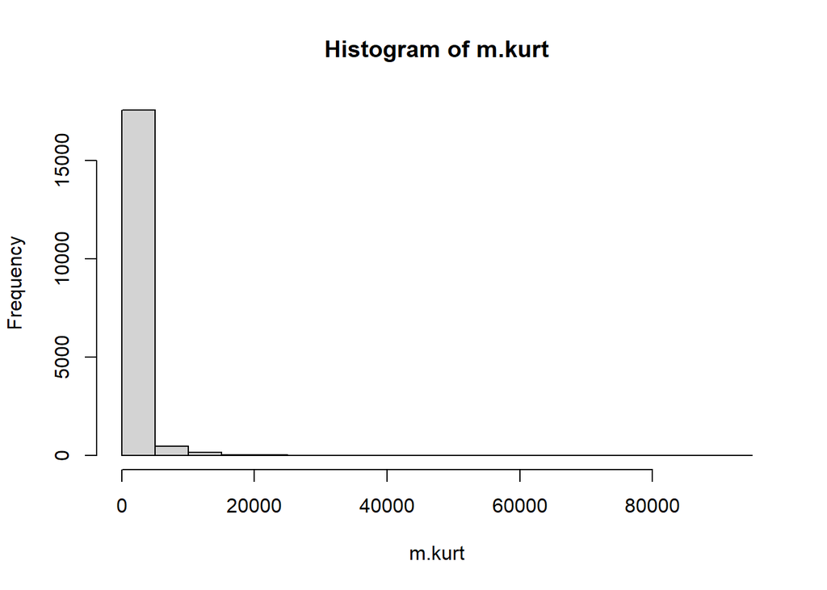

```r
hist(m.kurt)
```

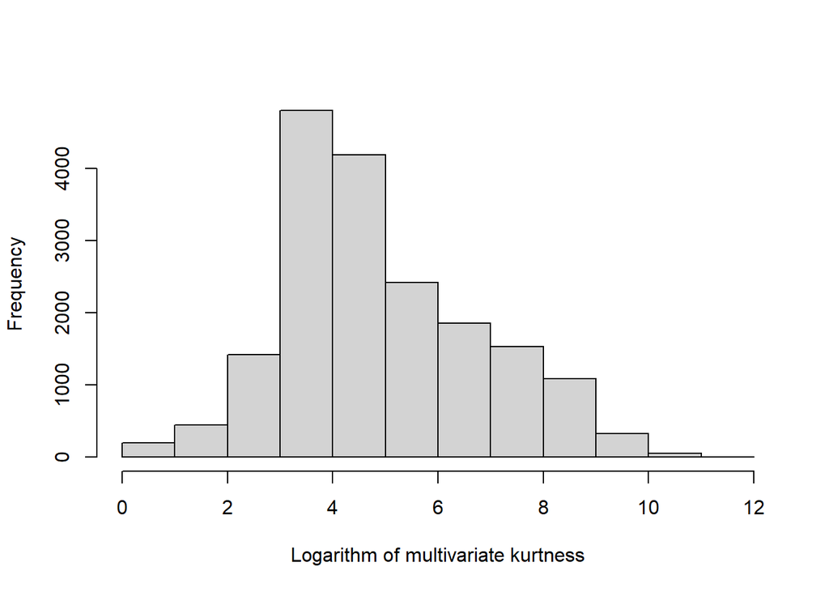

```r
hist(log(m.kurt+0.1), main="", xlab="Logarithm of multivariate kurtness")
```

Significant multivariate skewness or kurtosis

```r
mean(m.skew.pvalue < 0.05 | m.kurt.pvalue < 0.05)
```

```
## [1] 0.9595325
```

```
plot(log(n), log(m.skew+0.1), xlab='Sample size', ylab='Skewness')

plot(log(n), log(m.kurt), xlab='Sample size', ylab='Kurtosis')

plot(log(m.skew+0.1), log(m.kurt), xlab='Skewness', ylab='Kurtosis')
```

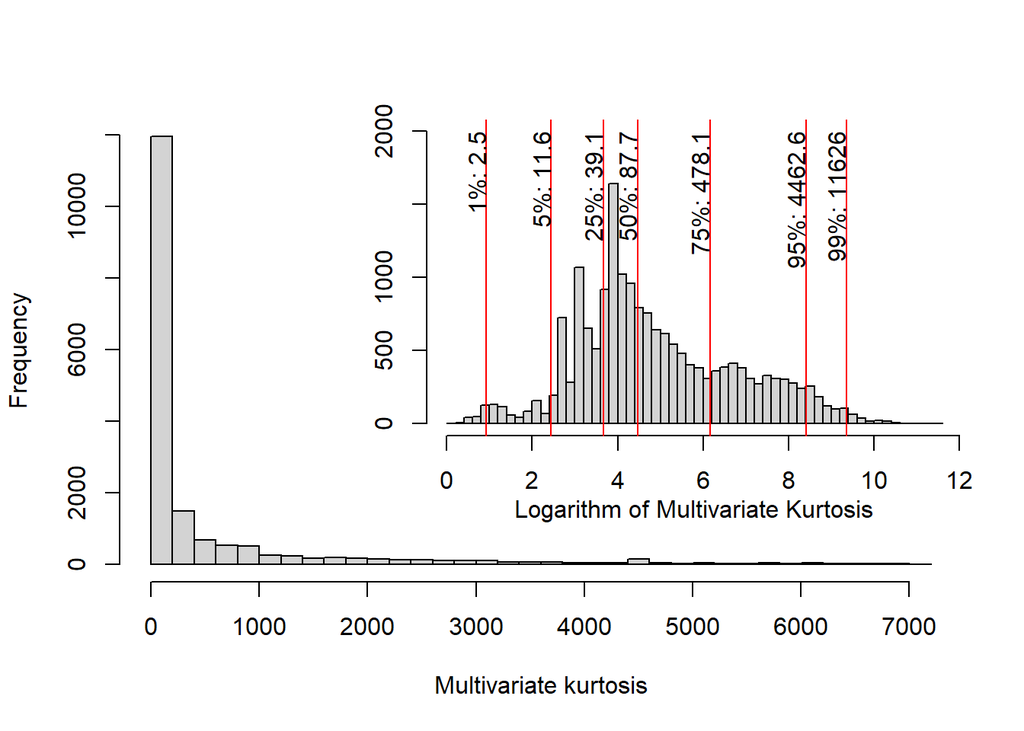

```r
### plot of the multivariate kurtosis
#pdf('mult_kurtosis.pdf')
hist(m.kurt[m.kurt < 7167], main='', xlab='Multivariate kurtosis', breaks=50)
par(fig=c(0.3, 1, 0.2, 1), new=TRUE, mgp=c(2, 1, 0))
hist(log(m.kurt), main='', xlab='Logarithm of Multivariate Kurtosis', ylab='', ylim=c(0, 2000), breaks=50)
abline(v=quantile(log(m.kurt), prob=c(.01, .05, .25, 0.5, .75, .95, .99)), col='red')
par(srt=90)
text(quantile(log(m.kurt), prob=c(.01, .05, .25, 0.5, .75, .95, .99)), 2000, labels=paste(c('1%', '5%', '25%', '50%', '75%', '95%', '99%'), round(quantile(m.kurt, prob=c(.01, .05, .25, 0.5, .75, .95, .99)), 1), sep=': '), pos=2, offset=0.3)
```

```r
par(mgp=c(3, 1, 0))
#dev.off()
```

## Multivariate skewness and kurtosis for different number of variables

```r
summary(mul.info[, 5]/p)
```

```
##     Min.  1st Qu.   Median     Mean  3rd Qu.     Max.
##    0.000    0.695    1.675    6.223    5.337 1212.070
```

```r
summary(m.kurt/p)
```

```
##      Min.   1st Qu.    Median      Mean   3rd Qu.      Max.
##    0.0066    7.6978   12.1134   21.8124   25.8955 1319.9330
```

```r
t(t(quantile(mul.info[, 5]/p, c(0.0001, .001, .005, 0.01, .025, .05, .1, .2, .25, .3, .4, .5, .6, .7, .75, .8, .9, .95, 0.975, 0.99, .995, .999, .9999))))
```

```
##                [,1]
## 0.01%  2.824705e-06
## 0.1%   1.008539e-04
## 0.5%   6.920554e-03
## 1%     3.291114e-02
## 2.5%   9.663224e-02
## 5%     1.728045e-01
## 10%    3.021573e-01
## 20%    5.696260e-01
## 25%    6.950052e-01
## 30%    8.447190e-01
## 40%    1.205310e+00
## 50%    1.675513e+00
## 60%    2.420106e+00
## 70%    3.960828e+00
## 75%    5.337309e+00
## 80%    7.403749e+00
## 90%    1.594893e+01
## 95%    2.687545e+01
## 97.5%  4.009884e+01
## 99%    6.493256e+01
## 99.5%  8.567760e+01
## 99.9%  1.494301e+02
## 99.99% 3.792162e+02
```

```r
t(t(quantile(m.kurt/p, c(0.0001, .001, .005, 0.01, .025, .05, .1, .2, .25, .3, .4, .5, .6, .7, .75, .8, .9, .95, 0.975, 0.99, .995, .999, .9999))))
```

```
##                [,1]
## 0.01%    0.01003402
## 0.1%     0.06927528
## 0.5%     1.70926994
## 1%       2.38285886
## 2.5%     3.32636531
## 5%       4.42470983
## 10%      5.51775993
## 20%      7.10784475
## 25%      7.69780317
## 30%      8.20563140
## 40%     10.00334483
## 50%     12.11338750
## 60%     15.28233636
## 70%     20.85820895
## 75%     25.89548187
## 80%     31.81931667
## 90%     52.47222000
## 95%     70.70490584
## 97.5%   90.61819274
## 99%    119.19520549
## 99.5%  138.89648073
## 99.9%  197.46057411
## 99.99% 437.71331659
```